# Practical Marchine Learning Project

November 20, 2015

## Background

The project goal is to use personal activity data collected from accelerometers on the belt, forearm, arm, and dumbell of 6 participants to create model using machine learning method to predict the accuracy.

The data for this project come from this source: http://groupware.les.inf.puc-rio.br/har.

Reference Velloso, E.; Bulling, A.; Gellersen, H.; Ugulino, W.; Fuks, H. Qualitative Activity Recognition of Weight Lifting Exercises. Proceedings of 4th International Conference in Cooperation with SIGCHI (Augmented Human ’13) . Stuttgart, Germany: ACM SIGCHI, 2013.

Read more: http://groupware.les.inf.puc-rio.br/har#ixzz3rvD1gkyq

## Study design

1. Prepare the data
2. Partition the data in training and test set
3. Build the model
4. Evaluate the model

### Loading the package for the study

## Prepare the data

Download and import the data from below source The training data for this project are available here: https://d396qusza40orc.cloudfront.net/predmachlearn/pml-training.csv

The test data are available here: https://d396qusza40orc.cloudfront.net/predmachlearn/pml-testing.csv

[output not shown]

[output cut: 86 more lines]

[output not shown]

[output cut: 313 more lines]

[output not shown]

From the review there are lots of NA require cleaning. We need remove them first.

```r
#select features and classe data
tdata2 <- tdata[, colSums(is.na(tdata)) == 0]
acceldata2 <- tdata2[grep("gyros|accel|magnet|classe", colnames(tdata2))]
dim(acceldata2)
```

```
## [1] 19622    41
```

```r
#read testing data
testdata <- read.csv("pml-testing.csv", header=TRUE)
dim(testdata)
```

```
## [1]  20 160
```

## Partition the data in training and test set

Partition the data to training and testing set using 70% setting

```r
#Partition data
set.seed(123)
inTrain <- createDataPartition(y=tdata2$classe, p=0.7, list=FALSE)
training <- acceldata2[inTrain,]
testing <- acceldata2[-inTrain,]
dim(training)
```

```
## [1] 13737    41
```

Review the correlation in the training set

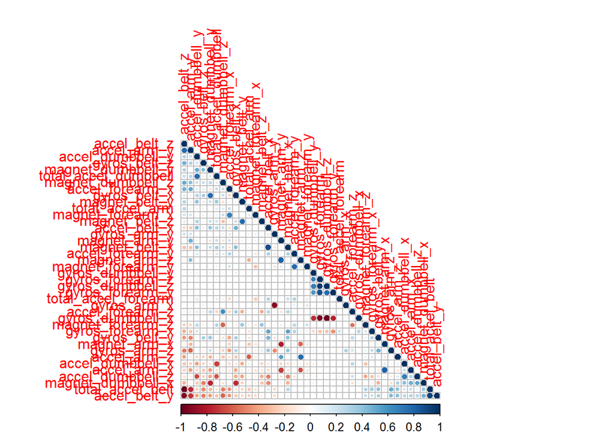

```r
cordata <- cor(training[,-41])
corrplot(cordata, method = "circle", type = "lower", order = "FPC")
```

## Build the model

First I select the method and fit the model. Then I will review the result from GBM and Random Forest models then select one with better accuracy for final prediction

### Set cross-validation and fit the model

```r
fitcontrol <- trainControl(method= "CV", number = 5)

#Train two models
modFitR <- train(training$classe ~., data = training, trControl = fitcontrol, method = "rf", verbose = FALSE)
print(modFitR, digits = 3)
```

```
## Random Forest
##
## 13737 samples
##    40 predictor
##     5 classes: 'A', 'B', 'C', 'D', 'E'
##
## No pre-processing
## Resampling: Cross-Validated (5 fold)
## Summary of sample sizes: 10989, 10988, 10990, 10991, 10990
## Resampling results across tuning parameters:
##
##   mtry  Accuracy  Kappa  Accuracy SD  Kappa SD
##    2    0.982     0.978  0.00332      0.00420
##   21    0.979     0.973  0.00259      0.00328
##   40    0.973     0.966  0.00160      0.00203
##
## Accuracy was used to select the optimal model using  the largest value.
## The final value used for the model was mtry = 2.
```

```r
modFitR$finalModel
```

```
##
## Call:
##  randomForest(x = x, y = y, mtry = param$mtry, verbose = FALSE)
##                Type of random forest: classification
##                      Number of trees: 500
## No. of variables tried at each split: 2
##
##         OOB estimate of  error rate: 1.46%
## Confusion matrix:
##      A    B    C    D    E class.error
## A 3897    2    1    5    1 0.002304147
## B   39 2595   22    1    1 0.023702032
## C    0   29 2362    5    0 0.014190317
## D    6    0   76 2168    2 0.037300178
## E    1    3    1    6 2514 0.004356436
```

From the result the OOB estimate of error rate: 1.46%

```r
modFitG <- train(training$classe ~., data = training, trControl = fitcontrol, method = "gbm", verbose = FALSE)
print(modFitG, digits = 3)
```

```
## Stochastic Gradient Boosting
##
## 13737 samples
##    40 predictor
##     5 classes: 'A', 'B', 'C', 'D', 'E'
##
## No pre-processing
## Resampling: Cross-Validated (5 fold)
## Summary of sample sizes: 10989, 10989, 10990, 10990, 10990
## Resampling results across tuning parameters:
##
##   interaction.depth  n.trees  Accuracy  Kappa  Accuracy SD  Kappa SD
##   1                   50      0.675     0.585  0.00521      0.00667
##   1                  100      0.747     0.678  0.00215      0.00287
##   1                  150      0.782     0.723  0.00500      0.00643
##   2                   50      0.790     0.733  0.00476      0.00619
##   2                  100      0.845     0.803  0.00453      0.00568
##   2                  150      0.873     0.840  0.00423      0.00534
##   3                   50      0.831     0.786  0.00665      0.00832
##   3                  100      0.883     0.851  0.00406      0.00509
##   3                  150      0.907     0.882  0.00223      0.00280
##
## Tuning parameter 'shrinkage' was held constant at a value of 0.1
##
## Tuning parameter 'n.minobsinnode' was held constant at a value of 10
## Accuracy was used to select the optimal model using  the largest value.
## The final values used for the model were n.trees = 150,
##  interaction.depth = 3, shrinkage = 0.1 and n.minobsinnode = 10.
```

```r
modFitG$finalModel
```

```
## A gradient boosted model with multinomial loss function.
## 150 iterations were performed.
## There were 40 predictors of which 36 had non-zero influence.
```

## Evaluate the model

### Predict the testing set data

```r
predR <- predict(modFitR, testing)
predG <- predict(modFitG, testing)
```

### Calculate the accuracy

```r
cmR <- confusionMatrix(predR, testing$classe)
cmG <- confusionMatrix(predG, testing$classe)

accuracy <- c(cmR$overall[[1]], cmG$overall[[1]])
accuracy
```

```
## [1] 0.9850467 0.9082413
```

Comparing both prediction results the Random Forest model has better accuracy which will be selected for predicting the test cases.

### Out of sample error

The out of sample error is (1-accuracy)*100 so the error is

```r
(1-cmR$overall[[1]])*100
```

```
## [1] 1.495327
```

### Predict the testing set data for 20 test cases

Using provided script I will create pridction result for submission

```r
class <- predict(modFitR, testdata)

answers <- class
pml_write_files = function(x){
  n = length(x)
  for(i in 1:n){
    filename = paste0("problem_id_",i,".txt")
    write.table(x[i],file=filename,quote=FALSE,row.names=FALSE,col.names=FALSE)
  }
}

#upload result
pml_write_files(answers)
```